# TÜİK Forecasting Project: Number of Visitors by Month (Tourism)

Emir ARMAN - 138721522

2026-06-02

# 1 Project Overview

# 2 Data Source and TÜİK Connection

[output not shown]

# 3 Data Access via tuikr

```r
# Load required packages
library(tuikr)
library(httr)
library(readxl)
library(dplyr)
library(tidyr)
library(forecast)
library(ggplot2)
library(knitr)
library(kableExtra)

# Step 1: Access TÜİK Tourism tables using tuikr
tables14 <- statistical_tables("14")

# Step 2: Get the URL for "Tourism expenditures, number of visitors and average expenditure per capita by months"
url_istab <- tables14$table_url[13]

# Step 3: Download the data using httr::GET() with appropriate headers
# This is necessary because TÜİK's SDMX API (nsiws.tuik.gov.tr) returns HTTP 401.
# The tuikr statistical_tables() function provides istab-type URLs accessible via httr.
temp_file <- tempfile(fileext = ".xls")

response <- GET(url_istab,
                add_headers(
                  "User-Agent" = "Mozilla/5.0 (Windows NT 10.0; Win64; x64) AppleWebKit/537.36",
                  "Accept"     = "application/vnd.openxmlformats-officedocument.spreadsheetml.sheet",
                  "Referer"    = "https://veriportali.tuik.gov.tr/"
                ),
                write_disk(temp_file, overwrite = TRUE))

cat("HTTP Status:", status_code(response), "\n")
```

```
## HTTP Status: 200
```

```r
# Step 4: Read the downloaded xls file
df_raw <- read_xls(temp_file)

cat("Raw data dimensions:", dim(df_raw), "\n")
```

```
## Raw data dimensions: 37 46
```

# 4 Use of TÜİK Data in R

```r
# Extract years from row 3 (every 3rd column starting from col 2)
years <- as.character(df_raw[3, seq(2, 46, by = 3)])
years <- years[!is.na(years)]
years_clean <- gsub("\\(1\\)", "", years)  # Remove "(1)" footnote from 2020

# Visitor count columns: 2nd column of each year group (cols 3, 6, 9, ...)
visitor_cols <- seq(3, 46, by = 3)

# Build tidy data frame: rows 6-17 are January through December
ts_data <- data.frame()

for (i in 1:length(years_clean)) {
  col_idx <- visitor_cols[i]
  values  <- as.numeric(as.character(unlist(df_raw[6:17, col_idx])))
  temp    <- data.frame(
    year     = as.integer(years_clean[i]),
    month    = 1:12,
    visitors = values
  )
  ts_data <- rbind(ts_data, temp)
}

# Add date column
ts_data$date <- as.Date(paste(ts_data$year, sprintf("%02d", ts_data$month), "01", sep = "-"))

# Remove NA rows (future months not yet published)
ts_clean <- ts_data[!is.na(ts_data$visitors), ]

cat("Total observations:", nrow(ts_clean), "\n")
```

```
## Total observations: 168
```

```r
cat("Period:", format(min(ts_clean$date), "%B %Y"), "to", format(max(ts_clean$date), "%B %Y"), "\n")
```

[output not shown]

```r
cat("Latest available observation:", format(max(ts_clean$date), "%B %Y"), "\n")
```

[output not shown]

```r
cat("Forecast target period: April 2026\n")
```

```
## Forecast target period: April 2026
```

```r
cat("Data access date:", format(Sys.Date()), "\n")
```

```
## Data access date: 2026-06-02
```

# 5 Exploratory Time Series Analysis

```r
# Create ts object
ts_visitors <- ts(ts_clean$visitors, start = c(2012, 1), frequency = 12)

# Summary statistics
summary(ts_visitors)
```

```
##    Min. 1st Qu.  Median    Mean 3rd Qu.    Max.
##   58076  567194  700686  681088  819109 1226894
```

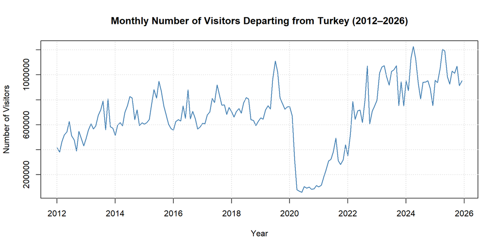

Actual Time Series: Monthly Number of Visitors

```r
# Plot actual series
plot(ts_visitors,
     main = "Monthly Number of Visitors Departing from Turkey (2012–2026)",
     ylab = "Number of Visitors",
     xlab = "Year",
     col  = "steelblue",
     lwd  = 1.5)
grid()
```

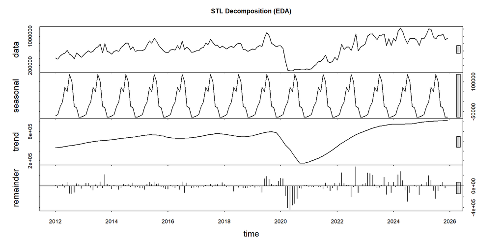

```r
# STL decomposition for EDA
stl_fit <- stl(ts_visitors, s.window = "periodic", robust = TRUE)
plot(stl_fit, main = "STL Decomposition (EDA)")
```

**Observations:**

- **Trend**: A clear upward trend from 2012 to 2019, a sharp drop in 2020 (COVID-19), and a strong recovery from 2021 onward.
- **Seasonality**: Strong and consistent seasonal pattern — visitor numbers peak in summer months (July–August) and dip in winter.
- **Structural break**: The pandemic in 2020 caused an extraordinary disruption, which is a known structural break.
- **Missing values**: None in the selected period.
- **Outliers**: 2020 values are extreme outliers due to COVID-19 travel restrictions.

# 6 Forecasting Methods

```r
# Full series
n_total <- length(ts_visitors)

# Use last 36 observations for accuracy evaluation
n_eval  <- 36
ts_eval <- tail(ts_visitors, n_eval)

# Actual values for accuracy calculation
actual <- as.numeric(ts_eval)
n      <- length(actual)
```

## 6.1 Naïve Forecasting

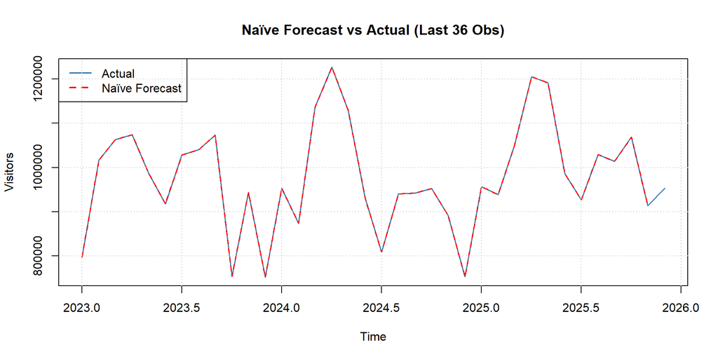

```r
# Naïve: forecast = previous period value
naive_fit    <- naive(ts_visitors, h = 1)
naive_next   <- as.numeric(naive_fit$mean[1])
naive_fitted <- c(NA, actual[-length(actual)])
naive_errors <- actual - naive_fitted
actual_naive <- actual[!is.na(naive_fitted)]
naive_fitted <- naive_fitted[!is.na(naive_fitted)]
naive_errors <- naive_errors[!is.na(naive_errors)]

# Plot
plot(ts_eval, main = "Naïve Forecast vs Actual (Last 36 Obs)",
     ylab = "Visitors", xlab = "Time", col = "steelblue", lwd = 1.5)
lines(ts(naive_fitted, start = c(2023, 1), frequency = 12),
      col = "red", lwd = 1.5, lty = 2)
legend("topleft", legend = c("Actual", "Naïve Forecast"),
       col = c("steelblue", "red"), lty = c(1, 2), lwd = 2)
grid()
```

## 6.2 Moving Average

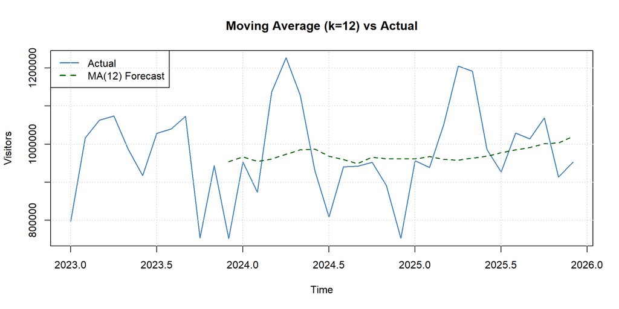

```r
# Window size = 12 (one full season) — captures seasonal cycle
ma_window  <- 12
ma_fitted  <- stats::filter(ts_eval, rep(1/ma_window, ma_window), sides = 1)
ma_fitted  <- as.numeric(ma_fitted)

# Remove NAs from the beginning
valid_idx    <- !is.na(ma_fitted)
ma_actual    <- actual[valid_idx]
ma_forecasts <- ma_fitted[valid_idx]
ma_errors    <- ma_actual - ma_forecasts

# Next period forecast: MA of last 12 observations
ma_next <- mean(tail(as.numeric(ts_visitors), 12))

# Plot
plot(ts_eval, main = "Moving Average (k=12) vs Actual",
     ylab = "Visitors", xlab = "Time", col = "steelblue", lwd = 1.5)
lines(ts(ma_fitted, start = c(2023, 1), frequency = 12),
      col = "darkgreen", lwd = 1.5, lty = 2)
legend("topleft", legend = c("Actual", "MA(12) Forecast"),
       col = c("steelblue", "darkgreen"), lty = c(1, 2), lwd = 2)
grid()
```

**Window size justification**: A window of 12 is chosen to match the monthly seasonal cycle, ensuring the moving average captures one full year of variation.

## 6.3 Weighted Moving Average

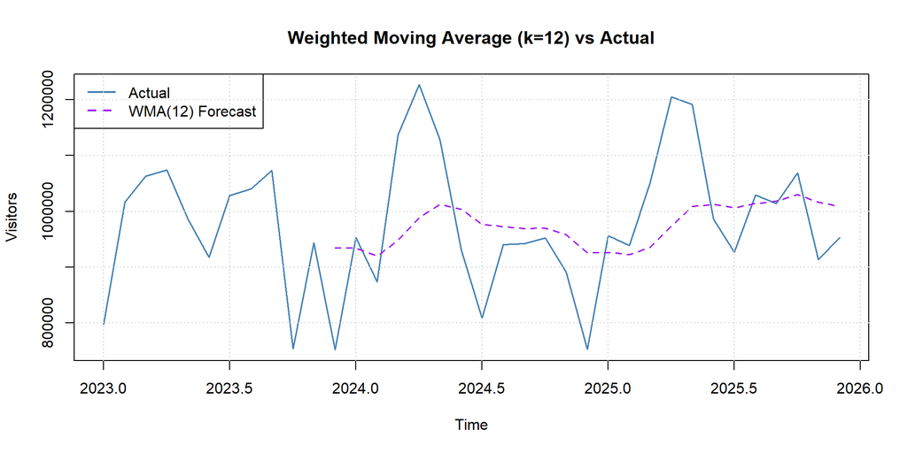

```r
# Weights: more recent observations get higher weight
# Last 12 months, linearly increasing weights
wma_window  <- 12
raw_weights <- 1:wma_window
wma_weights <- raw_weights / sum(raw_weights)

wma_fitted <- rep(NA, n)
for (i in wma_window:n) {
  wma_fitted[i] <- sum(wma_weights * actual[(i - wma_window + 1):i])
}

valid_idx2   <- !is.na(wma_fitted)
wma_actual   <- actual[valid_idx2]
wma_forecast <- wma_fitted[valid_idx2]
wma_errors   <- wma_actual - wma_forecast

# Next period forecast
last12       <- tail(as.numeric(ts_visitors), 12)
wma_next     <- sum(wma_weights * last12)

# Plot
plot(ts_eval, main = "Weighted Moving Average (k=12) vs Actual",
     ylab = "Visitors", xlab = "Time", col = "steelblue", lwd = 1.5)
lines(ts(wma_fitted, start = c(2023, 1), frequency = 12),
      col = "purple", lwd = 1.5, lty = 2)
legend("topleft", legend = c("Actual", "WMA(12) Forecast"),
       col = c("steelblue", "purple"), lty = c(1, 2), lwd = 2)
grid()
```

**Weighting logic**: Linearly increasing weights give more importance to recent observations, which is appropriate given the recovery trend post-2021.

## 6.4 Exponential Smoothing

```r
# Simple exponential smoothing — alpha optimized automatically
es_fit    <- ses(ts_visitors, h = 1)
es_alpha  <- es_fit$model$par["alpha"]
cat("Optimal alpha:", round(es_alpha, 4), "\n")
```

```
## Optimal alpha: 0.8237
```

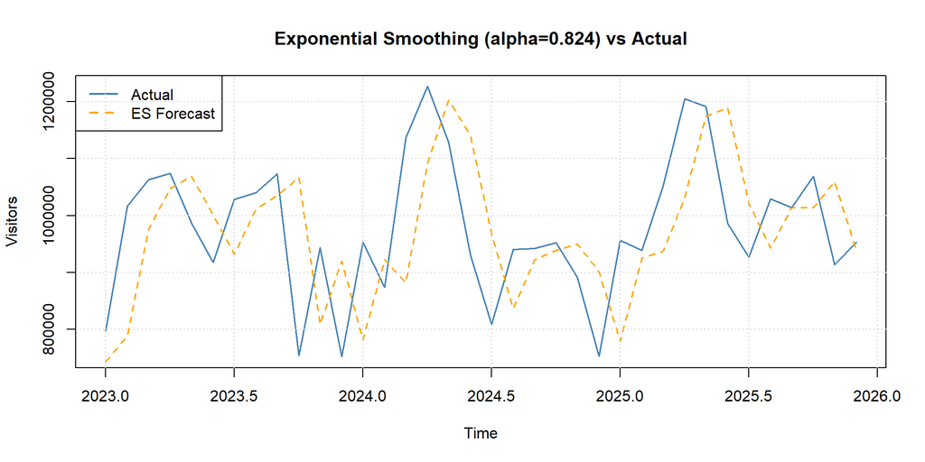

```r
es_fitted <- as.numeric(fitted(es_fit))
es_eval   <- tail(es_fitted, n_eval)
es_errors <- actual - es_eval
es_next   <- as.numeric(es_fit$mean[1])

# Plot
plot(ts_eval, main = paste0("Exponential Smoothing (alpha=", round(es_alpha,3), ") vs Actual"),
     ylab = "Visitors", xlab = "Time", col = "steelblue", lwd = 1.5)
lines(ts(es_eval, start = c(2023, 1), frequency = 12),
      col = "orange", lwd = 1.5, lty = 2)
legend("topleft", legend = c("Actual", "ES Forecast"),
       col = c("steelblue", "orange"), lty = c(1, 2), lwd = 2)
grid()
```

## 6.5 Trend-Adjusted Exponential Smoothing (Holt’s Method)

```r
# Holt's method: captures level + trend
holt_fit    <- holt(ts_visitors, h = 1)
holt_alpha  <- holt_fit$model$par["alpha"]
holt_beta   <- holt_fit$model$par["beta"]
cat("Alpha:", round(holt_alpha, 4), "| Beta:", round(holt_beta, 4), "\n")
```

```
## Alpha: 0.8277 | Beta: 1e-04
```

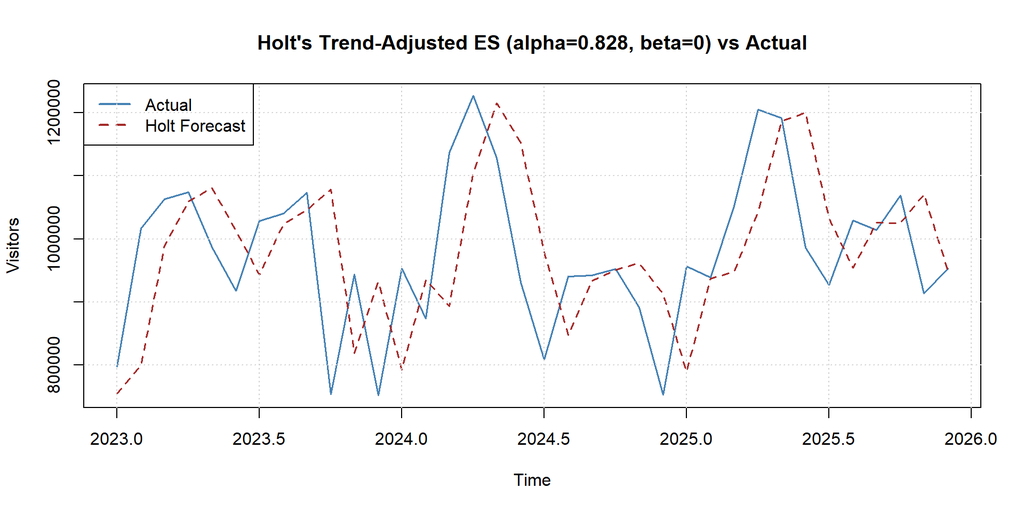

```r
holt_fitted <- as.numeric(fitted(holt_fit))
holt_eval   <- tail(holt_fitted, n_eval)
holt_errors <- actual - holt_eval
holt_next   <- as.numeric(holt_fit$mean[1])

# Plot
plot(ts_eval, main = paste0("Holt's Trend-Adjusted ES (alpha=", round(holt_alpha,3),
                             ", beta=", round(holt_beta,3), ") vs Actual"),
     ylab = "Visitors", xlab = "Time", col = "steelblue", lwd = 1.5)
lines(ts(holt_eval, start = c(2023, 1), frequency = 12),
      col = "brown", lwd = 1.5, lty = 2)
legend("topleft", legend = c("Actual", "Holt Forecast"),
       col = c("steelblue", "brown"), lty = c(1, 2), lwd = 2)
grid()
```

**Trend assessment**: The series shows a clear upward trend post-2021. Holt’s method is therefore applicable.

## 6.6 Linear Trend Projection

```r
# Time index
t_index   <- 1:n_total
lm_fit    <- lm(as.numeric(ts_visitors) ~ t_index)

cat("Intercept:", round(coef(lm_fit)[1], 2), "\n")
```

```
## Intercept: 532145.8
```

```r
cat("Slope:", round(coef(lm_fit)[2], 2), "\n")
```

```
## Slope: 1762.63
```

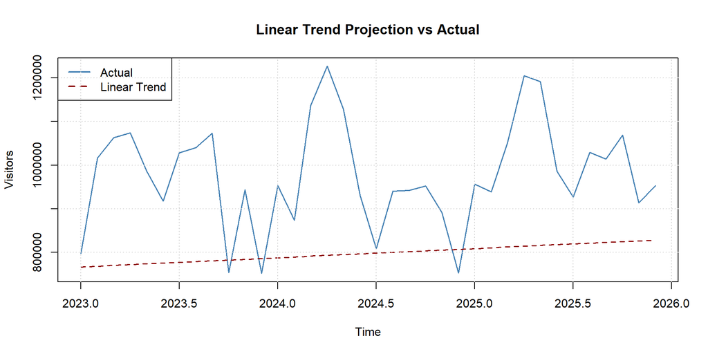

```r
lm_fitted  <- as.numeric(fitted(lm_fit))
lm_eval    <- tail(lm_fitted, n_eval)
lm_errors  <- actual - lm_eval

# Forecast next period (t = n_total + 1)
lm_next    <- predict(lm_fit, newdata = data.frame(t_index = n_total + 1))

# Plot
plot(ts_eval, main = "Linear Trend Projection vs Actual",
     ylab = "Visitors", xlab = "Time", col = "steelblue", lwd = 1.5)
lines(ts(lm_eval, start = c(2023, 1), frequency = 12),
      col = "darkred", lwd = 1.5, lty = 2)
legend("topleft", legend = c("Actual", "Linear Trend"),
       col = c("steelblue", "darkred"), lty = c(1, 2), lwd = 2)
grid()
```

**Interpretation**: The intercept represents the estimated visitor count at time zero (extrapolated baseline). The slope indicates the average monthly increase in visitor numbers over the study period.

## 6.7 Seasonal Indices

```r
# Calculate seasonal indices using ratio-to-moving-average method
# Step 1: 12-month centered moving average
ma12       <- stats::filter(as.numeric(ts_visitors), rep(1/12, 12), sides = 2)

# Step 2: Ratio of actual to MA
ratios     <- as.numeric(ts_visitors) / ma12

# Step 3: Average ratio by month = seasonal index
months_vec <- cycle(ts_visitors)
si         <- tapply(ratios, months_vec, mean, na.rm = TRUE)

# Normalize so indices sum to 12
si         <- si * (12 / sum(si))

cat("Seasonal Indices:\n")
```

```
## Seasonal Indices:
```

```r
month_names <- c("Jan","Feb","Mar","Apr","May","Jun",
                 "Jul","Aug","Sep","Oct","Nov","Dec")
si_df <- data.frame(Month = month_names, Seasonal_Index = round(si, 4))
print(si_df)
```

```
##    Month Seasonal_Index
## 1    Jan         0.9129
## 2    Feb         0.9668
## 3    Mar         1.0228
## 4    Apr         0.9934
## 5    May         1.0418
## 6    Jun         1.0428
## 7    Jul         1.1358
## 8    Aug         1.1373
## 9    Sep         1.0134
## 10   Oct         0.9545
## 11   Nov         0.8865
## 12   Dec         0.8919
```

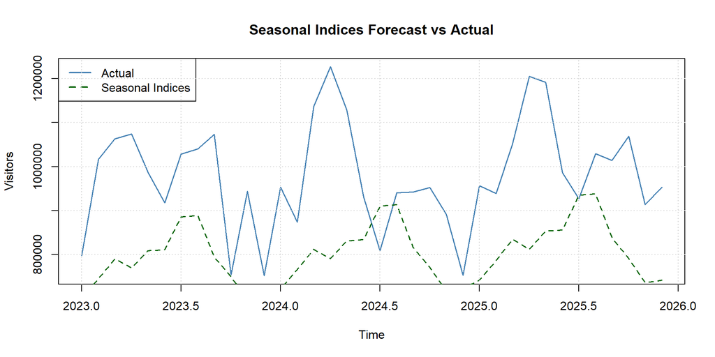

```r
# Deseasonalized series
deseason   <- as.numeric(ts_visitors) / si[months_vec]

# Trend on deseasonalized
t_index2   <- 1:n_total
lm_deseas  <- lm(deseason ~ t_index2)
trend_vals <- predict(lm_deseas, newdata = data.frame(t_index2 = 1:n_total))

# Reseasonalize
si_fitted  <- trend_vals * si[months_vec]
si_eval    <- tail(si_fitted, n_eval)
si_errors  <- actual - si_eval

# Next period forecast (April = month 4)
next_t     <- n_total + 1
next_trend <- predict(lm_deseas, newdata = data.frame(t_index2 = next_t))
si_next    <- next_trend * si[4]  # April index

# Plot
plot(ts_eval, main = "Seasonal Indices Forecast vs Actual",
     ylab = "Visitors", xlab = "Time", col = "steelblue", lwd = 1.5)
lines(ts(si_eval, start = c(2023, 1), frequency = 12),
      col = "darkgreen", lwd = 1.5, lty = 2)
legend("topleft", legend = c("Actual", "Seasonal Indices"),
       col = c("steelblue", "darkgreen"), lty = c(1, 2), lwd = 2)
grid()
```

**High season**: Months with index > 1 (July, August) indicate above-average visitor counts. **Low season**: Months with index < 1 (January, February) indicate below-average counts.

## 6.8 Additive Decomposition

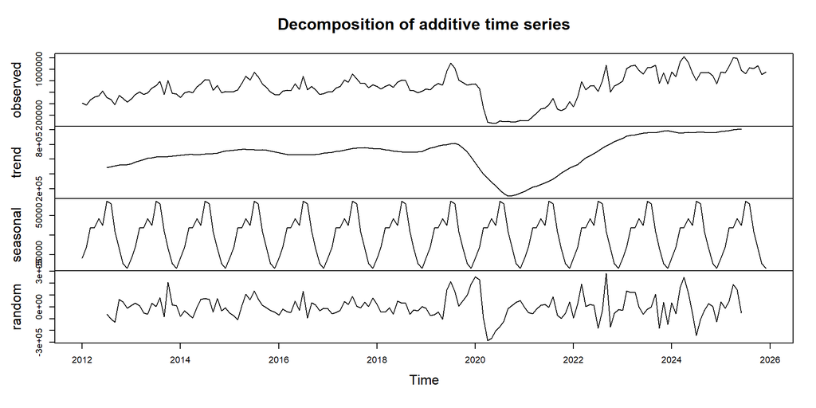

```r
# Classical additive decomposition
add_decomp  <- decompose(ts_visitors, type = "additive")
plot(add_decomp)
```

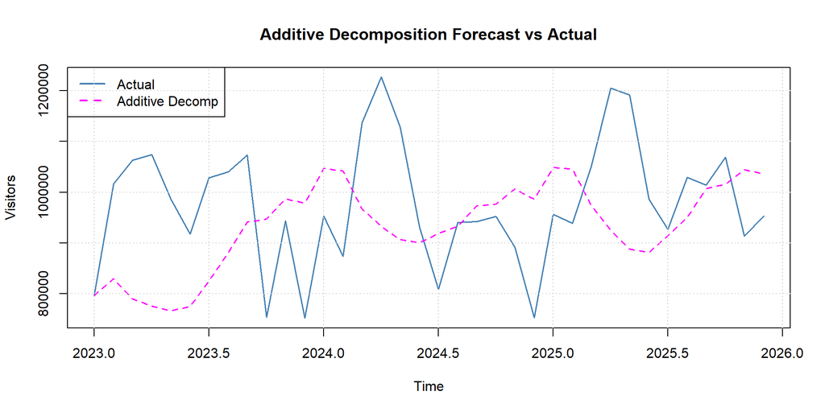

```r
# Reconstruct fitted values (trend + seasonal)
add_fitted  <- as.numeric(add_decomp$trend) + as.numeric(add_decomp$seasonal)
add_eval    <- tail(add_fitted[!is.na(add_fitted)], n_eval)
add_actual2 <- tail(actual, length(add_eval))
add_errors  <- add_actual2 - add_eval

# Forecast next period
last_trend  <- tail(as.numeric(add_decomp$trend)[!is.na(add_decomp$trend)], 1)
add_next    <- last_trend + as.numeric(add_decomp$seasonal)[4]  # April seasonal component

# Plot
plot(ts(add_actual2, start = c(2023, 1), frequency = 12),
     main = "Additive Decomposition Forecast vs Actual",
     ylab = "Visitors", xlab = "Time", col = "steelblue", lwd = 1.5)
lines(ts(add_eval, start = c(2023, 1), frequency = 12),
      col = "magenta", lwd = 1.5, lty = 2)
legend("topleft", legend = c("Actual", "Additive Decomp"),
       col = c("steelblue", "magenta"), lty = c(1, 2), lwd = 2)
grid()
```

## 6.9 Multiplicative Decomposition

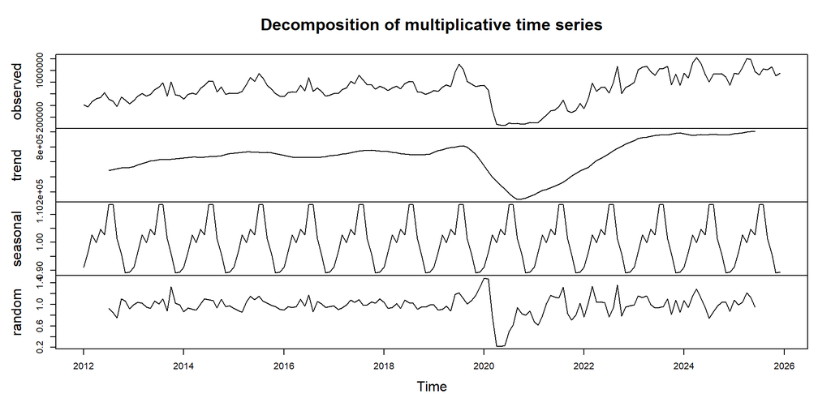

```r
# Classical multiplicative decomposition
mul_decomp  <- decompose(ts_visitors, type = "multiplicative")
plot(mul_decomp)
```

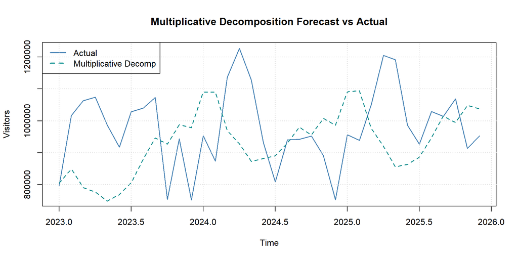

```r
# Reconstruct fitted values (trend * seasonal)
mul_fitted  <- as.numeric(mul_decomp$trend) * as.numeric(mul_decomp$seasonal)
mul_eval    <- tail(mul_fitted[!is.na(mul_fitted)], n_eval)
mul_actual2 <- tail(actual, length(mul_eval))
mul_errors  <- mul_actual2 - mul_eval

# Forecast next period
last_trend2 <- tail(as.numeric(mul_decomp$trend)[!is.na(mul_decomp$trend)], 1)
mul_next    <- last_trend2 * as.numeric(mul_decomp$seasonal)[4]

# Plot
plot(ts(mul_actual2, start = c(2023, 1), frequency = 12),
     main = "Multiplicative Decomposition Forecast vs Actual",
     ylab = "Visitors", xlab = "Time", col = "steelblue", lwd = 1.5)
lines(ts(mul_eval, start = c(2023, 1), frequency = 12),
      col = "darkcyan", lwd = 1.5, lty = 2)
legend("topleft", legend = c("Actual", "Multiplicative Decomp"),
       col = c("steelblue", "darkcyan"), lty = c(1, 2), lwd = 2)
grid()
```

## 6.10 Regression with Trend and Seasonal Dummy Variables

```r
# Create data frame with time index and seasonal dummies
reg_df           <- data.frame(
  visitors = as.numeric(ts_visitors),
  t        = 1:n_total,
  month    = factor(cycle(ts_visitors))
)

# Fit regression (month 1 = January is the reference category)
reg_fit    <- lm(visitors ~ t + month, data = reg_df)
summary(reg_fit)
```

```
##
## Call:
## lm(formula = visitors ~ t + month, data = reg_df)
##
## Residuals:
##     Min      1Q  Median      3Q     Max
## -701441  -25258   46703  130552  415379
##
## Coefficients:
##             Estimate Std. Error t value Pr(>|t|)
## (Intercept) 464815.9    72522.7   6.409 1.67e-09 ***
## t             1770.1      391.5   4.522 1.21e-05 ***
## month2       24707.0    92770.8   0.266    0.790
## month3       78972.5    92773.3   0.851    0.396
## month4       84717.6    92777.4   0.913    0.363
## month5      109375.7    92783.2   1.179    0.240
## month6       99402.4    92790.6   1.071    0.286
## month7      141913.6    92799.7   1.529    0.128
## month8      144942.0    92810.4   1.562    0.120
## month9       79375.3    92822.8   0.855    0.394
## month10      44612.9    92836.8   0.481    0.632
## month11       -323.5    92852.5  -0.003    0.997
## month12      -7357.4    92869.9  -0.079    0.937
## ---
## Signif. codes:  0 '***' 0.001 '**' 0.01 '*' 0.05 '.' 0.1 ' ' 1
##
## Residual standard error: 245400 on 155 degrees of freedom
## Multiple R-squared:  0.1521, Adjusted R-squared:  0.08648
## F-statistic: 2.317 on 12 and 155 DF,  p-value: 0.009463
```

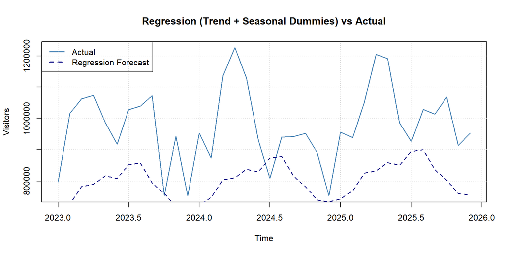

```r
reg_fitted <- as.numeric(fitted(reg_fit))
reg_eval   <- tail(reg_fitted, n_eval)
reg_errors <- actual - reg_eval

# Forecast April 2026 (t = n_total + 1, month = 4)
reg_next   <- predict(reg_fit,
                      newdata = data.frame(t = n_total + 1,
                                           month = factor(4, levels = 1:12)))

# Plot
plot(ts_eval, main = "Regression (Trend + Seasonal Dummies) vs Actual",
     ylab = "Visitors", xlab = "Time", col = "steelblue", lwd = 1.5)
lines(ts(reg_eval, start = c(2023, 1), frequency = 12),
      col = "navy", lwd = 1.5, lty = 2)
legend("topleft", legend = c("Actual", "Regression Forecast"),
       col = c("steelblue", "navy"), lty = c(1, 2), lwd = 2)
grid()
```

**Trend coefficient**: Represents the average monthly increase in visitor numbers after controlling for seasonality. **Seasonal dummies**: Each month coefficient shows the deviation from January (reference month).

# 7 Forecast Accuracy Comparison

```r
# Function to compute all required accuracy measures
calc_accuracy <- function(actual, forecast, method_name) {
  e    <- actual - forecast
  n    <- length(e)
  bias <- mean(e)
  mad  <- mean(abs(e))
  mse  <- mean(e^2)
  mape <- mean(abs(e / actual)) * 100
  rsfe <- sum(e)
  ts_  <- rsfe / mad  # Tracking Signal
  data.frame(
    Method          = method_name,
    Bias            = round(bias, 2),
    MAD             = round(mad, 2),
    MSE             = round(mse, 2),
    MAPE            = round(mape, 4),
    RSFE            = round(rsfe, 2),
    Tracking_Signal = round(ts_, 4),
    stringsAsFactors = FALSE
  )
}
```

```r
# Compute accuracy for each method
# Note: additive and multiplicative decomp may have fewer eval points due to NA trend edges
acc_naive <- calc_accuracy(actual,       naive_errors + actual - naive_errors,  "Naïve")
# Recalculate properly
acc_naive <- calc_accuracy(actual,                  actual - naive_errors,  "Naïve")
acc_ma    <- calc_accuracy(ma_actual,    ma_forecasts,   "Moving Average (k=12)")
acc_naive <- calc_accuracy(actual_naive, naive_fitted, "Naïve")
acc_wma   <- calc_accuracy(wma_actual,   wma_forecast,   "Weighted Moving Average (k=12)")
acc_es    <- calc_accuracy(actual,       actual - es_errors,    "Exponential Smoothing")
acc_lm    <- calc_accuracy(actual,       actual - lm_errors,    "Linear Trend Projection")
acc_si    <- calc_accuracy(actual,       actual - si_errors,    "Seasonal Indices")
acc_add   <- calc_accuracy(add_actual2,  add_eval,              "Additive Decomposition")
acc_mul   <- calc_accuracy(mul_actual2,  mul_eval,              "Multiplicative Decomposition")
acc_reg   <- calc_accuracy(actual,       actual - reg_errors,   "Regression Trend+Seasonal")

# Next period forecasts
next_forecasts <- c(
  round(naive_next, 0),
  round(ma_next, 0),
  round(wma_next, 0),
  round(es_next, 0),
  round(holt_next, 0),
  round(lm_next, 0),
  round(si_next, 0),
  round(add_next, 0),
  round(mul_next, 0),
  round(as.numeric(reg_next), 0)
)

# Combine all accuracy results
acc_all <- rbind(acc_naive, acc_ma, acc_wma, acc_es, acc_holt,
                 acc_lm, acc_si, acc_add, acc_mul, acc_reg)
acc_all$Next_Period_Forecast_Apr2026 <- next_forecasts

# Display table
kable(acc_all, caption = "Forecast Accuracy Comparison — All Methods",
      format = "html", align = "c") %>%
  kable_styling(bootstrap_options = c("striped", "hover", "condensed"),
                full_width = TRUE, font_size = 12)
```

Forecast Accuracy Comparison — All Methods

[output not shown]

```r
# Save accuracy table
dir.create("outputs/tables", recursive = TRUE, showWarnings = FALSE)
write.csv(acc_all, "outputs/tables/accuracy_comparison.csv", row.names = FALSE)
cat("Accuracy table saved.\n")
```

```
## Accuracy table saved.
```

# 8 Superior Method Selection

```r
# Find method with lowest MAPE
best_idx    <- which.min(acc_all$MAPE)
best_method <- acc_all$Method[best_idx]
cat("Method with lowest MAPE:", best_method, "\n")
```

```
## Method with lowest MAPE: Weighted Moving Average (k=12)
```

```r
cat("MAPE:", acc_all$MAPE[best_idx], "%\n")
```

```
## MAPE: 9.2017 %
```

**Selection Justification:**

The series exhibits both a clear **upward trend** (post-2021 recovery) and strong **monthly seasonality**. Methods that capture both components simultaneously are most suitable.

# 9 Final Next-Period Forecast

```r
# Final forecast for April 2026 using Regression (Trend + Seasonal Dummies)
final_value  <- round(as.numeric(reg_next), 0)
final_method <- "Regression with Trend and Seasonal Dummy Variables"
access_date  <- format(Sys.Date(), "%Y-%m-%d")

cat("=== FINAL FORECAST ===\n")
```

```
## === FINAL FORECAST ===
```

```r
cat("Selected Method       :", final_method, "\n")
```

```
## Selected Method       : Regression with Trend and Seasonal Dummy Variables
```

```r
cat("Data Access Date      :", access_date, "\n")
```

```
## Data Access Date      : 2026-06-02
```

```r
cat("Latest TÜİK Observation: March 2026\n")
```

[output not shown]

```r
cat("Forecast Target Period : April 2026\n")
```

```
## Forecast Target Period : April 2026
```

```r
cat("Forecasted Value      :", format(final_value, big.mark = ","), "visitors\n")
```

```
## Forecasted Value      : 848,689 visitors
```

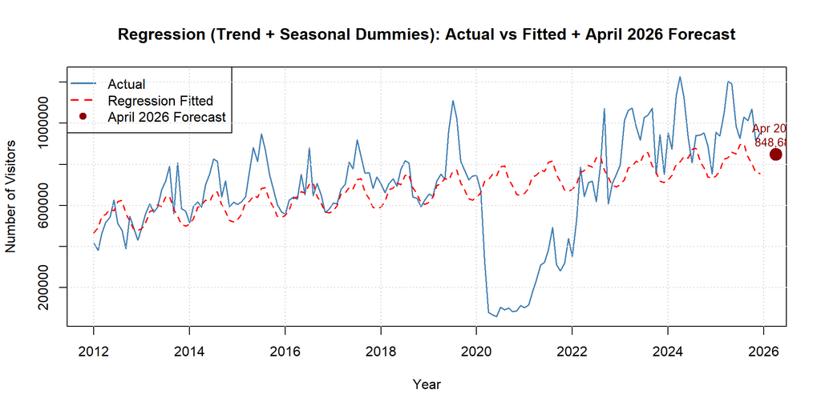

Superior Method: Actual vs Fitted + April 2026 Forecast

```r
# Plot showing fitted values and next-period forecast
ts_fitted_full <- ts(reg_fitted, start = c(2012, 1), frequency = 12)

# April 2026 point
apr2026_date <- as.Date("2026-04-01")

plot(ts_visitors,
     main = "Regression (Trend + Seasonal Dummies): Actual vs Fitted + April 2026 Forecast",
     ylab = "Number of Visitors",
     xlab = "Year",
     col  = "steelblue",
     lwd  = 1.5)
lines(ts_fitted_full, col = "red", lwd = 1.5, lty = 2)
points(2026 + 3/12, final_value, pch = 19, col = "darkred", cex = 2)
text(2026 + 3/12, final_value,
     labels = paste0("Apr 2026\n", format(final_value, big.mark = ",")),
     pos = 3, col = "darkred", cex = 0.85)
legend("topleft",
       legend = c("Actual", "Regression Fitted", "April 2026 Forecast"),
       col    = c("steelblue", "red", "darkred"),
       lty    = c(1, 2, NA), pch = c(NA, NA, 19), lwd = 2)
grid()
```

```r
# Save final forecast
final_df <- data.frame(
  Superior_Method          = final_method,
  Data_Access_Date         = access_date,
  Latest_Available_Obs     = "March 2026",
  Forecast_Target_Period   = "April 2026",
  Forecasted_Value         = final_value,
  MAPE                     = acc_all$MAPE[acc_all$Method == "Regression Trend+Seasonal"],
  MAD                      = acc_all$MAD[acc_all$Method  == "Regression Trend+Seasonal"],
  Tracking_Signal          = acc_all$Tracking_Signal[acc_all$Method == "Regression Trend+Seasonal"]
)

write.csv(final_df, "outputs/tables/final_forecast.csv", row.names = FALSE)
cat("Final forecast saved.\n")
```

```
## Final forecast saved.
```

# 10 Interpretation of Results

The regression model with trend and seasonal dummy variables forecasts approximately **848,689** visitors departing from Turkey in **April 2026**.

# 11 Limitations

1. **Structural break (COVID-19)**: The 2020 data represents an extraordinary disruption. Including these observations may distort trend and seasonal estimates.
2. **Short post-recovery period**: Only 3–4 years of post-COVID data are available, which may not fully capture the new baseline dynamics.
3. **No external variables**: The model does not include macroeconomic indicators, exchange rates, or geopolitical factors that influence outbound tourism.
4. **Linear trend assumption**: The regression assumes a constant linear trend, which may not hold if growth accelerates or decelerates.
5. **Data revisions**: TÜİK may revise earlier figures, which could affect accuracy measures retrospectively.

# 12 Reproducibility

To reproduce this analysis:

1. Install R (>= 4.6) and RStudio
2. Clone the repository
3. Install `renv` and run `renv::restore()` to restore the package environment
4. Open `forecasting_project.Rmd` and click **Knit**

All data are accessed programmatically via `tuikr` and `httr::GET()`. No manual data files are used.

# 13 Repository Structure

```
tuik-forecasting-project/
├── README.md
├── forecasting_project.Rmd
├── forecasting_project.html
├── outputs/
│   ├── tables/
│   │   ├── accuracy_comparison.csv
│   │   └── final_forecast.csv
│   └── figures/
├── R/
│   ├── data_import.R
│   ├── forecasting_methods.R
│   ├── accuracy_measures.R
│   └── plots.R
├── renv.lock
└── .gitignore
```

*Project completed by Emir ARMAN (138721522) — Forecasting Course*